# Name: Sandipto Sanyal

# PGID: 12010004

## Import necessary libraries

```r
library(repr) # to set the graph sizes
library(e1071) # statistical libraries
library(ggplot2) # create different graphs
library(ggpubr) # show mutiple ggplots
library("readxl") # to read excel data
library(dplyr)
```

1. Question 1
2. Question 2
3. Question 3
4. Question 4
5. Question 5
6. Question 6
7. Question 7
8. Question 8
9. Question 9
10. Question 10
11. Question 11
12. Question 12

# Question 1

## Given attributes

```r
u = 77.0
sigma = 3.4
## Visualize the distribution
# Create a sequence of numbers between 50 and 100 incrementing by 0.01.
x <- seq(50, 100, by = .01)
# Choose the mean and standard deviation as sigma
#to give probability distribution at each point of x
y <- dnorm(x, mean = u, sd = sigma)
```

## (a) Probability that random variable is less than 72.6

'Z Score is -1.29411764705883'

'Probability is 0.097812393434633'

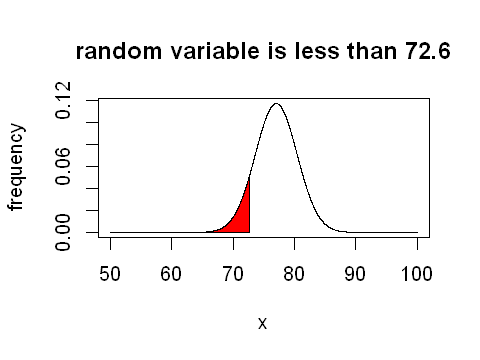

```r
## Let the random variable is n
n = 72.6
# set the figure size
options(repr.plot.width=4, repr.plot.height=3)
plot(x,y, type='l',
     main='random variable is less than 72.6',
    ylab='frequency')
polygon(c(x[x<=n], n), c(y[x<=n], 0), col="red")
## Find z score
z_score = (n-u)/sigma
## Find the p value
p = pnorm(z_score)
## probability that random variable is (a) less than 72.6
probabilities = p
paste(c('Z Score is ', z_score), collapse = " ")
paste(c('Probability is ', probabilities), collapse = " ")
```

## (b) Probability that random variable is greater than 88.5

'Z Score is 3.38235294117647'

'Probability is 0.000359338725646752'

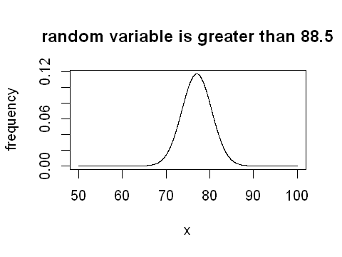

```r
## Let the random variable is n
n = 88.5
options(repr.plot.width=4, repr.plot.height=3)
plot(x,y, type='l',
     main='random variable is greater than 88.5',
    ylab='frequency')
polygon(x=c(n,x[x>=n]), y=c(0, y[x>=n]), col="red")
## Find z score
z_score = (n-u)/sigma
## Find the p value
p = pnorm(z_score)
## probability that random variable is (a) less than 72.6
probabilities = p
paste(c('Z Score is ', z_score), collapse = " ")
paste(c('Probability is ', 1-probabilities), collapse = " ")
```

**Interpretation of the graph:** We can see from step 4 above that the number 88.4 is more than 3 standard deviations away from our mean. This gives us a probability which is almost equal to 0 and hence no area is shaded by our plot.

## (c) Probability that random variable is between 81 and 84

'Z Score 1 is 1.17647058823529 ; Z Score 2 is 2.05882352941176'

'Probability is 0.0999478660096137'

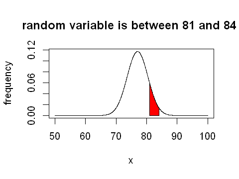

```r
## Let the random variable is in range [n1,n2]
n1 = 81; n2= 84
options(repr.plot.width=4, repr.plot.height=3)
plot(x,y, type='l',
     main='random variable is between 81 and 84 ',
    ylab='frequency')
polygon(x=c(n1,x[n1<=x & x<=n2],n2), y=c(0,y[n1<=x & x<=n2],0), col='red')
## Find z score
z_score1 = (n1-u)/sigma; z_score2 = (n2-u)/sigma
## Find the p value
p1 = pnorm(z_score1); p2 = pnorm(z_score2)
## probability that random variable is (a) less than 72.6
probabilities = p2 - p1
paste(c('Z Score 1 is ', z_score1, '; Z Score 2 is ', z_score2), collapse = " ")
paste(c('Probability is ', probabilities), collapse = " ")
```

## (d) Probability that random variable is between 56 and 92

'Z Score 1 is -6.17647058823529 ; Z Score 2 is 4.41176470588235'

'Probability is 0.999994873097099'

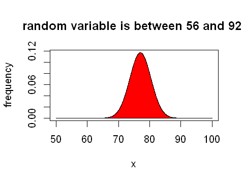

```r
## Let the random variable is in range [n1,n2]
n1 = 56; n2= 92
options(repr.plot.width=4, repr.plot.height=3)
plot(x,y, type='l',
     main='random variable is between 56 and 92 ',
    ylab='frequency')
polygon(x=c(n1,x[n1<=x & x<=n2],n2), y=c(0,y[n1<=x & x<=n2],0), col='red')
## Find z score
z_score1 = (n1-u)/sigma; z_score2 = (n2-u)/sigma
## Find the p value
p1 = pnorm(z_score1); p2 = pnorm(z_score2)
probabilities = p2 - p1
paste(c('Z Score 1 is ', z_score1, '; Z Score 2 is ', z_score2), collapse = " ")
paste(c('Probability is ', probabilities), collapse = " ")
```

**Inference from the above plot:** In step 6 we can see that we are taking the upper bound and lower bound between [-6, 4.4] standard deviations. Thus in normal distribution all data lie within this range

# Question 2

## Given attributes

```r
u = 145.0
sigma = 12
## Visualize the distribution
# Create a sequence of numbers between 50 and 100 incrementing by 0.01.
x <- seq(100, 200, by = .01)
# Choose the mean and standard deviation as sigma
#to give probability distribution at each point of x
y <- dnorm(x, mean = u, sd = sigma)
```

## (a) Find percentage of car racers whose finish time is between 130 and 160 minutes

'Z Score 1 is -1.25 ; Z Score 2 is 1.25'

'percentage of car racers whose finish time is between 130 and 160 minutes 78.8700452666289 %'

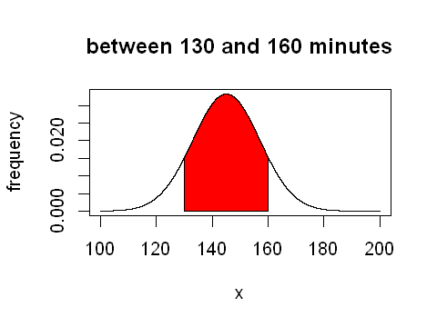

```r
## Let the random variable is in range [n1,n2]
n1 = 130; n2= 160
options(repr.plot.width=4, repr.plot.height=3)
plot(x,y, type='l',
     main='between 130 and 160 minutes',
    ylab='frequency')
polygon(x=c(n1,x[n1<=x & x<=n2],n2), y=c(0,y[n1<=x & x<=n2],0), col='red')
## Find z score
z_score1 = (n1-u)/sigma; z_score2 = (n2-u)/sigma
## Find the p value
p1 = pnorm(z_score1); p2 = pnorm(z_score2)
## probability that random variable is (a) less than 72.6
probabilities = p2 - p1
paste(c('Z Score 1 is ', z_score1, '; Z Score 2 is ', z_score2), collapse = " ")
paste(c('percentage of car racers whose finish time is between 130 and 160 minutes ', probabilities*100, '%'), collapse = " ")
```

## (b) Find percentage of car racers whose finish time is less than 130 minutes

'Z Score is -1.25'

'percentage of car racers whose finish time is less than 130 minutes 10.5649773666855 %'

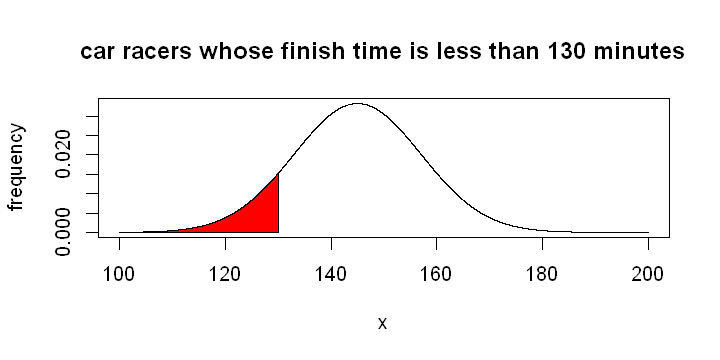

```r
## Let the random variable is n
n = 130
# set the figure size
options(repr.plot.width=6, repr.plot.height=3)
plot(x,y, type='l',
     main='car racers whose finish time is less than 130 minutes',
    ylab='frequency')
polygon(c(x[x<=n], n), c(y[x<=n], 0), col="red")
## Find z score
z_score = (n-u)/sigma
## Find the p value
p = pnorm(z_score)
## probability that random variable is (a) less than 72.6
probabilities = p
paste(c('Z Score is ', z_score), collapse = " ")
paste(c('percentage of car racers whose finish time is less than 130 minutes ', probabilities*100, '%'), collapse = " ")
```

# Question 3

Since the experiment is of binary outcome **True or False** and also has more than 1 trials = 15 it is a case of binomial distribution with n = no. of outcomes = 15, probability of success of each outcome = p = 0.5

## (a) What is the probability that the student got first five questions correct.

This means we have to find P(C,C,C,C,C,W,W,W,W,W,W,W,W,W,W). For each question probability of success is 0.5. So for five questions it is 0.5<sup>5</sup> and for rest of the 10 questions probabilit of failure will be (1-0.5)<sup>10</sup>.  
Since we are wanting probability that the student got first 5 question correct at a row we will calculate the required probability as **0.5<sup>5</sup> x (1-0.5)<sup>10</sup>**

```r
probabilities = (0.5)**5*(0.5)**10
paste(c('probability that the student got first five questions correct ', probabilities), collapse = " ")
```

'probability that the student got first five questions correct 3.0517578125e-05'

## (b) What is the probability that the student got five questions correct

For this we want to know the probability that the student got any of the 5 question correct. Obviously this probability is expected to be much higher than what we found in previous question.

1. Firstly we are choosing any five questions out of 15 questions. So no. of choices will be <sup>15</sup>C<sub>5</sub>.
2. Now for each question probability of success is 0.5. So for five questions it is 0.5<sup>5</sup> and for rest of the 10 questions probabilit of failure will be (1-0.5)<sup>10</sup>.
3. Thus total probability of our student getting **any** 5 questions correct is **<sup>15</sup>C<sub>5</sub> x 0.5<sup>5</sup> x (1-0.5)<sup>10</sup>**

```r
nCr = dim(combn(15,5))[2]
probabilities = nCr*0.5^5*0.5^10
paste(c('probability that the student got five questions correct ', probabilities), collapse = " ")
```

'probability that the student got five questions correct 0.091644287109375'

### Visualize the above using R plot

Also we can calculate the same using R package as below

'probability that the student got five questions correct 0.0916442871093751'

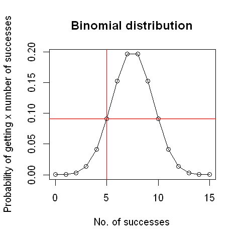

```r
no_of_trials = 15; no_of_success = 5
# Create a sequence of 15 numbers which denotes our maximum number of trials and each denotes number of successes
#which are incremented by 1.
x <- seq(0,no_of_trials,by = 1)
# Create the binomial distribution.size is the number of trials, prob= Probability of success
y <- dbinom(x=x, size=no_of_trials, prob=0.5)
# set the figure size
options(repr.plot.width=4, repr.plot.height=4)
plot(x,y, type='o',
     main='Binomial distribution',
     xlab='No. of successes',
    ylab='Probability of getting x number of successes')
abline(a=NULL, b=NULL, h=y[x==no_of_success], v=no_of_success, col='red')
probabilities = y[x==no_of_success]
paste(c('probability that the student got five questions correct ', probabilities), collapse = " ")
```

# Question 4

We are given probability of marks being in range 35 and 42 as 68%. Below are the thought proces:

1. We know in a normal distribution 68% of the data lies between +/-1 standard deviation.
2. So mean - 1sd = 35 and mean + 1sd = 42.
3. Solving them mean = (35+42)/2 = **38.5**
4. Standard deviation = 42 - mean = **3.5**

# Question 5

Let's consider the two event as A as clearing the first exam and B as clearing the second exam. Its given that:

1. P(A ∩ B) = 30%
2. P(A) = 55%
3. So we are asked to find P(B|A) = P(A ∩ B)/P(A) = 30/55 = 0.55 = **54.54%**

# Question 6

Let's consider the two event as TV as having a TV and DVD as having a DVD. Its given that:

1. P(TV ∩ DVD) = 62%
2. P(TV) = 82%
3. So we are asked to find P(DVD|TV) = P(TV ∩ DVD)/P(TV) = 62/82 = 0.756 = **75.6%**

# Question 7

Given we have coin toss means we have two ouputs and more than one trials we are dealing with a random variable which follows binomial distribution. The following data is given:

1. no. of trials = n = 3
2. Probability of success i.e. having Head = p = 0.5

## (a) probability of getting all three heads

We are asked to find **P(HHH) = 0.5^3 = 0.125**

## (b) probability of getting exactly 1 head

For this

1. We first have <sup>3</sup>C<sub>1</sub> choices for getting only 1 head in all 3 trials.
2. Probability of getting 1 head is 0.5
3. Probability of not getting other tosses as head is (1-0.5)<sup>2</sup>

So the required probabality = **<sup>3</sup>C<sub>1</sub> x 0.5<sup>1</sup> x (1-0.5)<sup>2</sup> = 0.375**

```r
3*0.5*0.5^2
```

0.375

## (c) Given that you have seen exactly one head, what is the probability of getting at least two heads?

- P(getting at least two heads) = P(getting exactly two heads) + P(getting all heads) = **<sup>3</sup>C<sub>2</sub> x 0.5<sup>2</sup> x (1-0.5)<sup>1</sup> + <sup>3</sup>C<sub>3</sub> x 0.5<sup>3</sup> x (1-0.5)<sup>0</sup> = 0.5**

```r
dim(combn(3,2))[2]*0.5^2*0.5^1 + dim(combn(3,3))[2]*0.5^3*0.5^0
```

0.5

# Question 8

Let x be the random variable that represents the speed of cars. x has μ = 90 and σ = 10. We have to find the probability that x is higher than 100 or P(x > 100)

## Visualize the normal distribution

Here we will visualize the above normal distributions for a better understanding.

```r
# let the random variable be n
n = 100
u = 90
sigma = 10
x = seq(50,150, by=0.1)
y = dnorm(x, mean=u, sd=sigma)
```

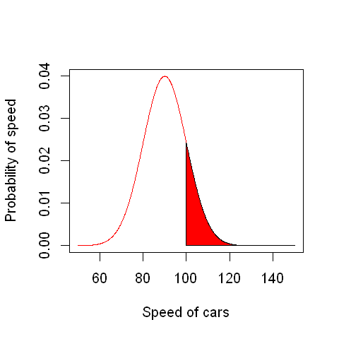

```r
options(repr.plot.width=4, repr.plot.height=4)
plot(x,y,type="l",col="red", xlab='Speed of cars', ylab='Probability of speed')
polygon(x=c(n,x[x>=n],150), y=c(0,y[x>=n],0), col="red")
```

```r
probability = 1 - pnorm(q=n, mean=u, sd=sigma)
print(c("Probability of speed of a car >= 100 ",probability))
```

```
[1] "Probability of speed of a car >= 100 "
[2] "0.158655253931457"
```

# Question 9

Here we have two sets having color mix of M&Ms as follows:

- 1994: (30% Brown, 20% Yellow, 20% Red, 10% Green, 10% Orange, 10% Tan)
- 1995 and afterwards: (24% Blue, 20% Green, 16% Orange, 14% Yellow, 13% Red, 13% Brown)

So we have to find the probability of P(Bag from 1994|M&M is yellow).  
From total probability theorem P(M&M is yellow) = P(M&M is yellow|Bag from 1994) x P(Bag from 1994) + P(M&M is yellow|Bag **Not** from 1994) x P(Bag **Not** from 1994) = 0.2 *0.5 + 0.14* 0.5 = 0.17  
By Bayes theorem we know that P(Bag from 1994|M&M is yellow) = P(M&M is yellow|Bag from 1994).P(Bag from 1994)/P(M&M is yellow) = (0.2 * 0.5)/0.17 = **0.588**

# Question 10

**Note:** All datasets were downloaded from https://in.finance.yahoo.com/ in the same timeframe.  
Import and view first 6 rows of the dataset. Since we have dates we will suppres R converting strings to Factors as it will cause issues with date conversion.

```r
walmart_df = read.csv('datasets/WMT.csv', stringsAsFactors = FALSE)
head(walmart_df)
```

| Date | Open | High | Low | Close | Adj.Close | Volume |
| --- | --- | --- | --- | --- | --- | --- |
| 2020-01-15 | 114.63 | 115.87 | 114.52 | 115.28 | 115.28 | 7454200 |
| 2020-01-16 | 115.50 | 115.93 | 115.28 | 115.90 | 115.90 | 5369400 |
| 2020-01-17 | 116.05 | 116.30 | 114.64 | 114.96 | 114.96 | 10045000 |
| 2020-01-21 | 114.59 | 115.69 | 114.52 | 115.59 | 115.59 | 7353700 |
| 2020-01-22 | 115.22 | 116.53 | 115.18 | 116.10 | 116.10 | 4926100 |
| 2020-01-23 | 116.21 | 116.31 | 115.04 | 115.81 | 115.81 | 4305100 |

## See the structure of the dataframe

This we will do to check how R is parsing each column of our imported dataframe

```r
str(walmart_df)
```

```
'data.frame':	41 obs. of  7 variables:
 $ Date     : chr  "2020-01-15" "2020-01-16" "2020-01-17" "2020-01-21" ...
 $ Open     : num  115 116 116 115 115 ...
 $ High     : num  116 116 116 116 117 ...
 $ Low      : num  115 115 115 115 115 ...
 $ Close    : num  115 116 115 116 116 ...
 $ Adj.Close: num  115 116 115 116 116 ...
 $ Volume   : int  7454200 5369400 10045000 7353700 4926100 4305100 4383400 7018400 5270200 3775500 ...
```

## (a) Calculate the mean and the standard deviation of the stock prices.

```r
print(c("Mean of Adj.Close: ", mean(walmart_df$Adj.Close), "SD Adj.Close: ", sd(walmart_df$Adj.Close)))
```

```
[1] "Mean of Adj.Close: " "115.433170414634"    "SD Adj.Close: "
[4] "2.80787373339469"
```

## (b) Get the corresponding data for Sears and calculate the mean and the standard deviation

Import sears holding dataset and view first 6 rows.

```r
shld_df = read.csv('datasets/SHLDQ.csv', stringsAsFactors = FALSE)
head(shld_df)
```

| Date | Open | High | Low | Close | Adj.Close | Volume |
| --- | --- | --- | --- | --- | --- | --- |
| 2020-01-15 | 0.19 | 0.20 | 0.19 | 0.19 | 0.19 | 315800 |
| 2020-01-16 | 0.19 | 0.21 | 0.19 | 0.20 | 0.20 | 207700 |
| 2020-01-17 | 0.21 | 0.24 | 0.20 | 0.23 | 0.23 | 739000 |
| 2020-01-21 | 0.23 | 0.25 | 0.20 | 0.25 | 0.25 | 2035200 |
| 2020-01-22 | 0.24 | 0.27 | 0.24 | 0.25 | 0.25 | 512500 |
| 2020-01-23 | 0.27 | 0.27 | 0.25 | 0.26 | 0.26 | 157100 |

```r
str(shld_df)
```

```
'data.frame':	41 obs. of  7 variables:
 $ Date     : chr  "2020-01-15" "2020-01-16" "2020-01-17" "2020-01-21" ...
 $ Open     : num  0.19 0.19 0.21 0.23 0.24 0.27 0.26 0.25 0.36 0.38 ...
 $ High     : num  0.2 0.21 0.24 0.25 0.27 0.27 0.27 0.37 0.41 0.39 ...
 $ Low      : num  0.19 0.19 0.2 0.2 0.24 0.25 0.25 0.25 0.36 0.3 ...
 $ Close    : num  0.19 0.2 0.23 0.25 0.25 0.26 0.25 0.36 0.37 0.33 ...
 $ Adj.Close: num  0.19 0.2 0.23 0.25 0.25 0.26 0.25 0.36 0.37 0.33 ...
 $ Volume   : int  315800 207700 739000 2035200 512500 157100 186500 2109000 1487300 1399100 ...
```

**Calculate the mean and standard deviation for Sears**

```r
print(c("Mean of Adj.Close: ", mean(shld_df$Adj.Close), "SD Close.Last: ", sd(shld_df$Adj.Close)))
```

```
[1] "Mean of Adj.Close: " "0.251219512195122"   "SD Close.Last: "
[4] "0.0514390475199152"
```

## Part (c)

The coefficient of variation (CV)is defined as the ratio of the standard deviation over the mean.Calculate the CV of Wal-•‐Mart and Kmart stock prices.

```r
print(c("CV of Walmart: ", sd(walmart_df$Adj.Close)/mean(walmart_df$Adj.Close)))
print(c("CV of Sears: ", sd(shld_df$Adj.Close)/mean(shld_df$Adj.Close)))
```

```
[1] "CV of Walmart: "  "0.02432466961887"
[1] "CV of Sears: "     "0.204757373622964"
```

## Part (d)

If the CV of the daily stock prices is taken as an indicator of risk of the stock, how do Wal-•‐Mart and Kmart stocks compare in terms of risk? (There are better measures of risk, but we will use CV in this exercise.)

From the page Coefficient of Variation | Definition | Formula | Example. (n.d.). Retrieved March 15, 2020, from https://xplaind.com/428087/coefficient-of-variation it is clear that Sears having higher CV is a riskier company to invest.

## Part (e)

Get the corresponding data of the Dow Jones Industrial Average (DJIA) and compute its CV. How do Wal-•‐ Mart and Kmart stocks compare with the DJIA in terms of risk?

```r
dji_df = read.csv('datasets/DJI.csv', stringsAsFactors = FALSE)
head(dji_df)
```

| Date | Open | High | Low | Close | Adj.Close | Volume |
| --- | --- | --- | --- | --- | --- | --- |
| 2020-01-15 | 28901.80 | 29127.59 | 28897.35 | 29030.22 | 29030.22 | 260270000 |
| 2020-01-16 | 29131.95 | 29300.32 | 29131.95 | 29297.64 | 29297.64 | 252110000 |
| 2020-01-17 | 29313.31 | 29373.62 | 29289.91 | 29348.10 | 29348.10 | 321820000 |
| 2020-01-21 | 29269.05 | 29341.21 | 29146.47 | 29196.04 | 29196.04 | 320640000 |
| 2020-01-22 | 29263.63 | 29320.20 | 29172.26 | 29186.27 | 29186.27 | 283440000 |
| 2020-01-23 | 29111.02 | 29190.47 | 28966.98 | 29160.09 | 29160.09 | 307060000 |

```r
str(dji_df)
```

```
'data.frame':	41 obs. of  7 variables:
 $ Date     : chr  "2020-01-15" "2020-01-16" "2020-01-17" "2020-01-21" ...
 $ Open     : num  28902 29132 29313 29269 29264 ...
 $ High     : num  29128 29300 29374 29341 29320 ...
 $ Low      : num  28897 29132 29290 29146 29172 ...
 $ Close    : num  29030 29298 29348 29196 29186 ...
 $ Adj.Close: num  29030 29298 29348 29196 29186 ...
 $ Volume   : int  260270000 252110000 321820000 320640000 283440000 307060000 380010000 337270000 330140000 302290000 ...
```

```r
print(c("CV of Walmart: ", sd(walmart_df$Adj.Close)/mean(walmart_df$Adj.Close)))
print(c("CV of Sears: ", sd(shld_df$Adj.Close)/mean(shld_df$Adj.Close)))
print(c("CV of DJIA: ", sd(dji_df$Adj.Close)/mean(dji_df$Adj.Close)))
```

```
[1] "CV of Walmart: "  "0.02432466961887"
[1] "CV of Sears: "     "0.204757373622964"
[1] "CV of DJIA: "       "0.0752052357496378"
```

**Inference:** In terms of risk of investment Sears > DJIA > Walmart.

## Part (f)

Suppose you bought 100 shares of Wal-•‐Mart stock three months ago and held it. What are the mean and the standard deviation of the daily market price of your holding for the three months?

```r
# multiply number of shares = 100 with each element in walmart_df$Close
holdings = 100*walmart_df$Adj.Close
print(c("Mean of our holdings = ", mean(holdings)))
print(c("SD of our holdings = ", sd(holdings)))
```

```
[1] "Mean of our holdings = " "11543.3170414634"
[1] "SD of our holdings = " "280.787373339469"
```

# Question 11

For this problem, consider the dataset Prob_Assignment_Dataset.xlsx attached. As the vigilant monitors of the Zappos.Com website, we are obsessed with who is coming to our website and what they do during their visit. This challenge requires you to look at data similar to that which Analytics teams at Zappos would use to assess the overall performance of the business.

## Read the dataset

Read the dataset and get a snapshot of the columns and data.

## View structure of the dataset

```r
df = read_excel('datasets//Prob_Assignment_Dataset (2).xlsx', sheet='Example_Data')
data_reference = read_excel('datasets//Prob_Assignment_Dataset (2).xlsx', sheet='Data_Reference', col_names = TRUE)
str(df)
```

```
* `` -> ...2
```

```
Classes 'tbl_df', 'tbl' and 'data.frame':	21061 obs. of  12 variables:
 $ day               : POSIXct, format: "2013-01-01" "2013-01-01" ...
 $ site              : chr  "Acme" "Acme" "Sortly" "Acme" ...
 $ new_customer      : num  1 1 1 1 1 1 1 1 0 0 ...
 $ platform          : chr  "Android" "BlackBerry" "iPad" "Windows" ...
 $ visits            : num  24 0 0 922 11 384 14 1 41 448 ...
 $ distinct_sessions : num  16 0 0 520 10 214 10 0 27 368 ...
 $ orders            : num  14 0 0 527 11 213 4 0 6 36 ...
 $ gross_sales       : num  1287 13 98 60753 1090 ...
 $ bounces           : num  4 0 0 149 0 65 4 0 6 80 ...
 $ add_to_cart       : num  16 0 0 610 11 245 7 0 12 79 ...
 $ product_page_views: num  104 1 0 3914 4 ...
 $ search_page_views : num  192 0 0 7367 19 ...
```

## View first 6 rows of dataframe

```r
head(df)
```

| day | site | new_customer | platform | visits | distinct_sessions | orders | gross_sales | bounces | add_to_cart | product_page_views | search_page_views |
| --- | --- | --- | --- | --- | --- | --- | --- | --- | --- | --- | --- |
| 2013-01-01 | Acme | 1 | Android | 24 | 16 | 14 | 1287 | 4 | 16 | 104 | 192 |
| 2013-01-01 | Acme | 1 | BlackBerry | 0 | 0 | 0 | 13 | 0 | 0 | 1 | 0 |
| 2013-01-01 | Sortly | 1 | iPad | 0 | 0 | 0 | 98 | 0 | 0 | 0 | 0 |
| 2013-01-01 | Acme | 1 | Windows | 922 | 520 | 527 | 60753 | 149 | 610 | 3914 | 7367 |
| 2013-01-01 | Botly | 1 | Android | 11 | 10 | 11 | 1090 | 0 | 11 | 4 | 19 |
| 2013-01-01 | Acme | 1 | Macintosh | 384 | 214 | 213 | 28129 | 65 | 245 | 1783 | 3255 |

## Data reference

View the data reference of the above dataset

```r
data_reference
```

| Data column definitions | ...2 |
| --- | --- |
| day | The calendar day |
| site | Company site visited by users |
| new_customer | 0 = returning customer; 1 = new customer; null = neither |
| platform | The type of device used by a website visitor |
| visits | The number of distinct website visits; 1 session may have multiple visits |
| distinct_sessions | The number of distinct website visitors; 1 session may have multiple visits |
| orders | The number of website orders |
| gross_sales | The total gross sales for website orders |
| bounces | The number of visits that only viewed one page |
| add_to_cart | The number of visits that added a product to cart |
| product_page_views | The number of product pages viewed |
| search_page_views | The number of search pages viewed |
| NA | NA |
| Requested metrics formulae | NA |
| conversion_rate | ='orders'/'visits' |
| bounce_rate | ='bounces'/'visits' |
| add_to_cart_rate | ='add_to_cart'/visits' |

## Convert categorical columns column to factors

Here we convert the categorical columns site, new_customer and platform to factors.

```r
df$new_customer = factor(df$new_customer)
df$site = factor(df$site)
df$platform = factor(df$platform)
```

## View the some general summary of the dataframe

```r
summary(df)
```

```
      day                            site      new_customer    platform
 Min.   :2013-01-01 00:00:00   Acme    :7392   0   :7066    iOS    :3435
 1st Qu.:2013-06-10 00:00:00   Botly   : 804   1   :5736    Android:3172
 Median :2013-08-21 00:00:00   Pinnacle:5725   NA's:8259    Windows:2399
 Mean   :2013-07-30 13:23:22   Sortly  :5532                MacOSX :2054
 3rd Qu.:2013-10-27 00:00:00   Tabular : 804                Linux  :2036
 Max.   :2013-12-31 00:00:00   Widgetry: 804                (Other):7555
                                                            NA's   : 410
     visits       distinct_sessions     orders         gross_sales
 Min.   :     0   Min.   :     0    Min.   :   0.00   Min.   :     1
 1st Qu.:     3   1st Qu.:     2    1st Qu.:   0.00   1st Qu.:    79
 Median :    24   Median :    19    Median :   0.00   Median :   851
 Mean   :  1935   Mean   :  1515    Mean   :  62.38   Mean   : 16473
 3rd Qu.:   360   3rd Qu.:   274    3rd Qu.:   7.00   3rd Qu.:  3145
 Max.   :136057   Max.   :107104    Max.   :4916.00   Max.   :707642
                                                      NA's   :9576
    bounces         add_to_cart     product_page_views search_page_views
 Min.   :    0.0   Min.   :   0.0   Min.   :     0     Min.   :     0
 1st Qu.:    0.0   1st Qu.:   0.0   1st Qu.:     3     1st Qu.:     4
 Median :    5.0   Median :   4.0   Median :    53     Median :    82
 Mean   :  743.3   Mean   : 166.3   Mean   :  4358     Mean   :  8584
 3rd Qu.:   97.0   3rd Qu.:  43.0   3rd Qu.:   708     3rd Qu.:  1229
 Max.   :54512.0   Max.   :7924.0   Max.   :187601     Max.   :506629
```

## Univariate data analysis

Below we will perform univariate dataset analysis for our dataset.

### Visualization of categorical variables

#### Company Site vs. Customer type

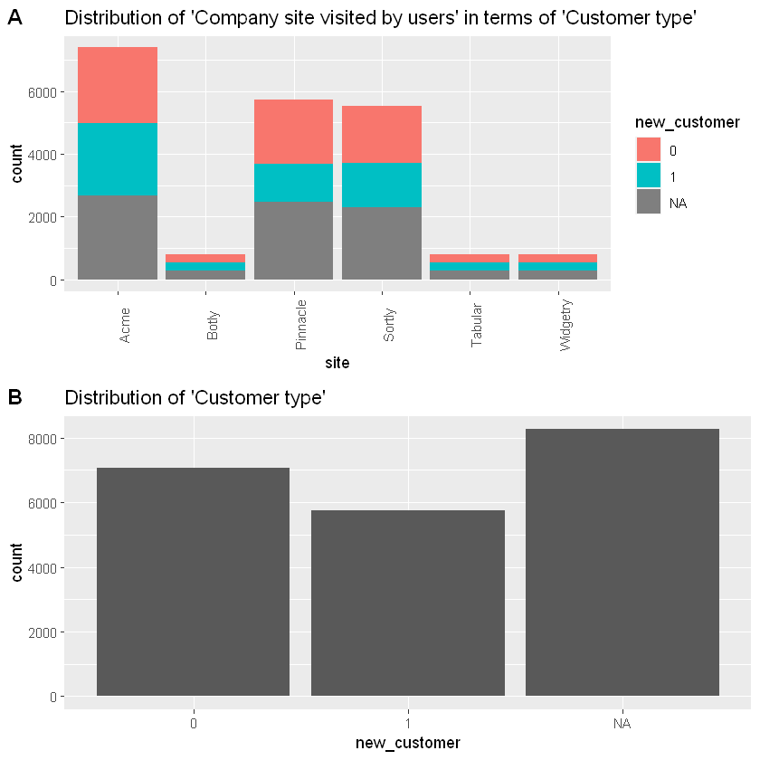

```r
options(repr.plot.width=7, repr.plot.height=7)
g1 = ggplot(data=df) +
    aes(site,fill=new_customer) +
    geom_bar() +
    scale_x_discrete() +
    theme(axis.text.x = element_text(angle = 90, vjust = 1)) +
    labs(title="Distribution of 'Company site visited by users' in terms of 'Customer type'")

g2 = ggplot(data=df) +
    aes(new_customer) +
    geom_bar() +
    scale_x_discrete() +
    labs(title="Distribution of 'Customer type'")


figure <- ggarrange(g1, g2,
                    labels = c("A", "B"),
                    ncol = 1, nrow = 2)
figure
```

**Inference:** From the above histograms it is seen that there is a huge numbers of customers visiting Acme website. Also from graph B it is seen that we have almost uniform distribution of customer types.

#### Company site vs. Platform

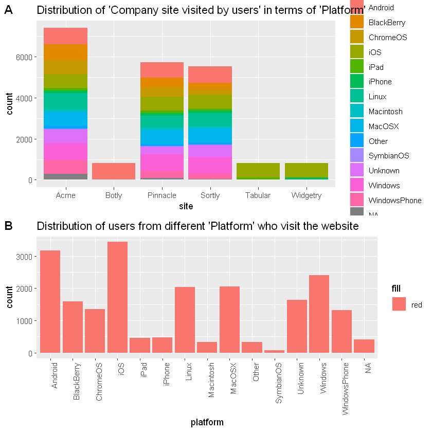

```r
options(repr.plot.width=7, repr.plot.height=7)
g1 = ggplot(data=df) +
    aes(site,fill=platform) +
    geom_bar() +
    scale_x_discrete() +
    labs(title="Distribution of 'Company site visited by users' in terms of 'Platform'")
g2 = ggplot(data=df) +
    aes(platform,fill="red") +
    geom_bar() +
    scale_x_discrete() +
    theme(axis.text.x = element_text(angle = 90, hjust = 1)) +
    labs(title="Distribution of users from different 'Platform' who visit the website")
figure <- ggarrange(g1, g2,
                    labels = c("A", "B"),
                    ncol = 1, nrow = 2)
figure
```

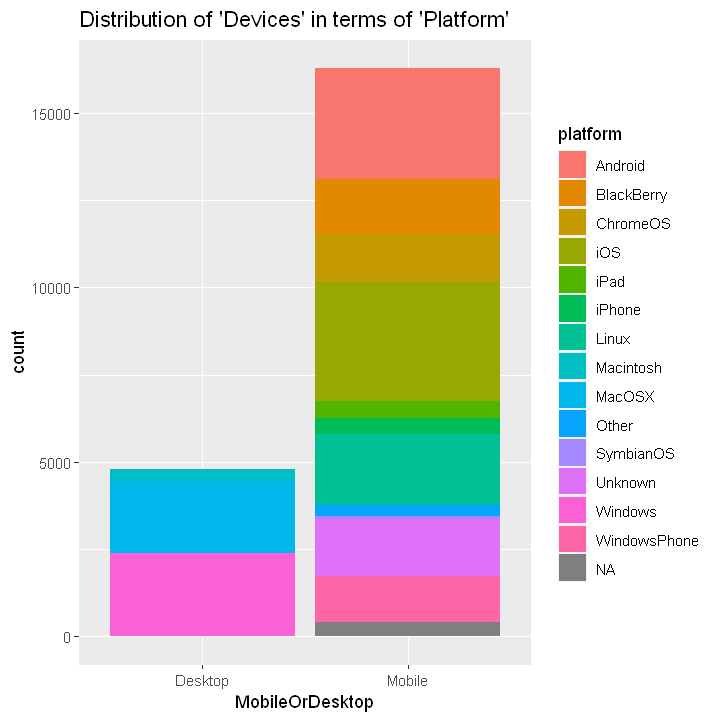

```r
options(repr.plot.width=6, repr.plot.height=6)
df$MobileOrDesktop = ifelse(df$platform %in% c("Macintosh","MacOSX","Windows"), "Desktop", "Mobile")
g1 = ggplot(data=df) +
    aes(MobileOrDesktop,fill=platform) +
    geom_bar() +
    scale_x_discrete() +
    labs(title="Distribution of 'Devices' in terms of 'Platform'")
g1
```

### Visualization of numerical variables

#### View distribution of gross_sales

```r
print(c("Skewness = ",skewness(x=df$gross_sales, na.rm=TRUE)))
print(c("Standard deviation = ",sd(x=df$gross_sales, na.rm=TRUE)))
print('Other statistics')
summary(df$gross_sales)
```

```
[1] "Skewness = "      "4.69585808752638"
[1] "Standard deviation = " "51111.3546047801"
[1] "Other statistics"
```

```
   Min. 1st Qu.  Median    Mean 3rd Qu.    Max.    NA's
      1      79     851   16473    3145  707642    9576
```

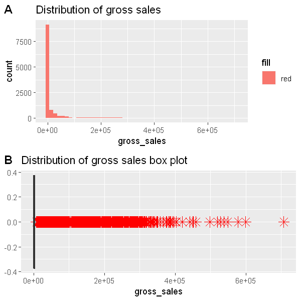

```r
options(repr.plot.width=5, repr.plot.height=5)
g1 = ggplot(data=df) +
    aes(gross_sales, fill="red") +
    geom_histogram(bins=50, na.rm = TRUE) +
    scale_x_continuous() +
    labs(title="Distribution of gross sales")
g2 = ggplot(data=df) +
    aes(gross_sales) +
    geom_boxplot(outlier.colour="red", outlier.shape=8, outlier.size=4, na.rm = TRUE) +
    labs(title="Distribution of gross sales box plot")

ggarrange(g1, g2,
        labels = c("A", "B"),
         nrow=2)
```

**Inference:** Below are some of the observations for the feature gross_sales:

1. It is highly right skewed in nature
2. Too many points are outliers as shown in the box plot.

#### Visualize the Requested metrics

Visualize the below metrics:

1. conversion_rate ='orders'//'visits'
2. bounce_rate ='bounces'//'visits'
3. add_to_cart_rate ='add_to_cart'//visits'

```r
df$conversion_rate = df$orders/df$visits
df$bounce_rate = df$bounces/df$visits
df$add_to_cart_rate = df$add_to_cart/df$visits
```

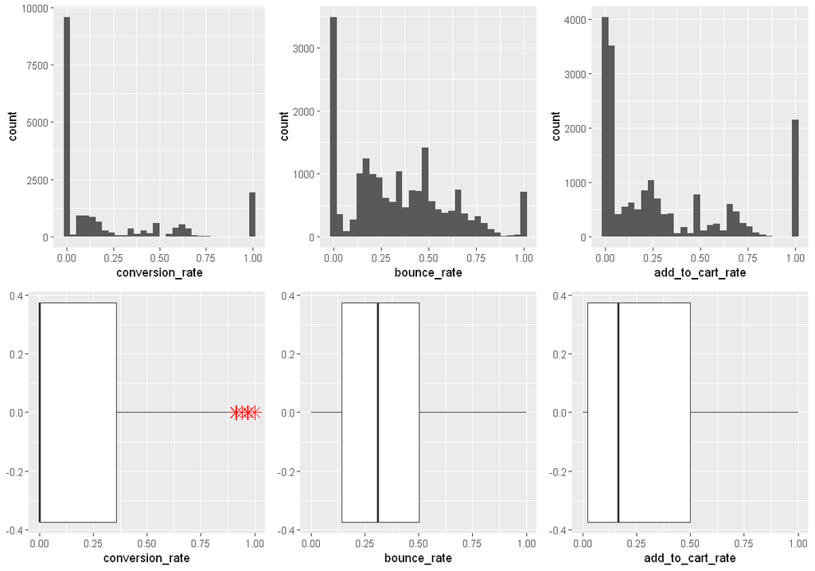

```r
options(repr.plot.width=10, repr.plot.height=7)
g1 = ggplot(data=df) +
    aes(x=conversion_rate) +
    geom_histogram(bins=30) +
    scale_x_continuous()
g2 = ggplot(data=df) +
    aes(x=bounce_rate) +
    geom_histogram(bins=30) +
    scale_x_continuous()
g3 = ggplot(data=df) +
    aes(x=add_to_cart_rate) +
    geom_histogram(bins=30) +
    scale_x_continuous()
g4 = ggplot(data=df) +
    aes(x=conversion_rate) +
    geom_boxplot(outlier.colour="red", outlier.shape=8, outlier.size=4, na.rm = TRUE)
g5 = ggplot(data=df) +
    aes(x=bounce_rate) +
    geom_boxplot(outlier.colour="red", outlier.shape=8, outlier.size=4, na.rm = TRUE)
g6 = ggplot(data=df) +
    aes(x=add_to_cart_rate) +
    geom_boxplot(outlier.colour="red", outlier.shape=8, outlier.size=4, na.rm = TRUE)
fig <- ggarrange(g1,g2,g3, g4, g5, g6,
         nrow=2, ncol=3, widths=c(3,3,3))
plot(fig)
```

```r
print(c("Skewness of conversion_rate = ",skewness(x=df$conversion_rate, na.rm=TRUE)))
print(c("Skewness of bounce_rate = ",skewness(x=df$bounce_rate, na.rm=TRUE)))
print(c("Skewness of add_to_cart_rate = ",skewness(x=df$add_to_cart_rate, na.rm=TRUE)))
```

```
[1] "Skewness of conversion_rate = " "1.40847749447916"
[1] "Skewness of bounce_rate = " "0.551734521506788"
[1] "Skewness of add_to_cart_rate = " "1.02474189614549"
```

**Inference:** The above analysis shows high right skewness in conversion rate and add_to_cart_rate than that of bounce_rate.

# Question 12

Consider the same dataset as earlier. Now perform bi-•‐variate data analysis as discussed in last class to find out relationships between different variables. Write a short description on what you find in the analyses along with any tables, graphs. You do not have to analyze all variables, any 3-•‐4 that interest you most should be the focus here.

## Bivariate data analysis

### Orders vs. Product page views

Here we will view the variation among orders and product_page_views. Though we will plot for all the sites but our main focus will be for three top sites as we found in Question 11

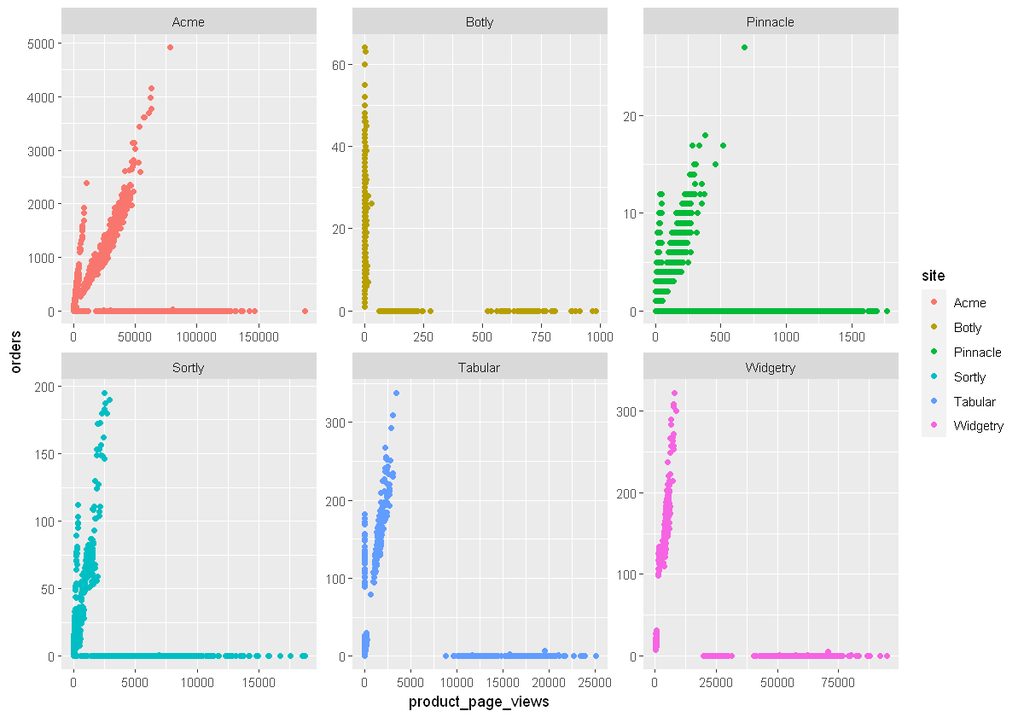

```r
options(repr.plot.width=10, repr.plot.height=7)
g1 = ggplot(df) +
    aes(x=product_page_views, y=orders, color=site) +
    geom_point() +
    facet_wrap(~site, scales="free")
g1
```

**Observations:** The above plots show three types of customers:

1. Low product_page_views but ordering the product: These are the type very sure which product to buy so directly searching and buying the product keeping the product_page_views low. This is highly seen for **Botly** demarcated by vertical line.
2. Orders after quite a bit of searching: Mostly seen for Acme and Pinnacle. Also from Question 11 we have seen that **Acme** has highest number of visits. Here also Acme has highest number of orders.
3. Low orders high product_page_views: Customers are viewing the product pages but are not ordering. This part becomes interesting for sites **Pinnacle and Sortly**. From Question 11 we have seen that these two sites are doing quite good in terms of site visits. Above plots also say the same story. But it is evident that the number of website orders are very low for these sites (Strikingly low for Pinnacle).  
   **Inference**:
   1. **Acme** is doing good in terms of people visiting the products page and number of orders from that page.
   2. **Pinnacle** is showing the trend people are viewing the products page but ordering very less.

### Conversion rate vs. Add to cart rate

Here we will view the relationship between conversion rate vs. Add to cart rate. Under ideal scenarios we expect them to follow a linear curve.

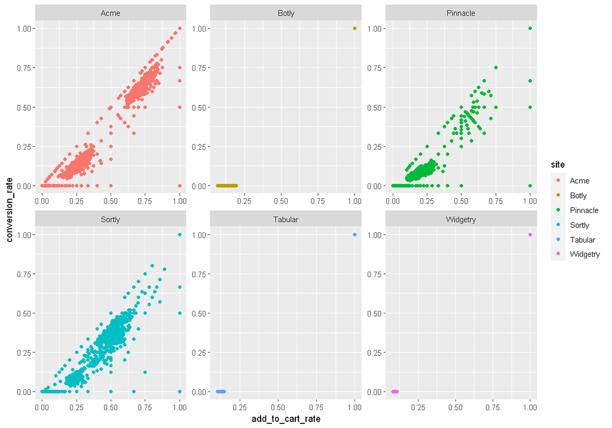

```r
options(repr.plot.width=10, repr.plot.height=7)
g1 = ggplot(df) +
    aes(x=add_to_cart_rate, y=conversion_rate, color=site) +
    geom_point() +
    facet_wrap(~site, scales="free")
g1
```

**Inference:** From the above plots below are our observations:

1. For Acme, Pinnacle and Sortly it is seen that majority of the people are adding items to cart but are not ordering all of them.
2. Other websites conversion rate is extremely low.

### Variation of all numerical features with time span

Below we will visualize the variation of all the features in same time frame

```
$title
[1] "Variation of gross sales with time"

attr(,"class")
[1] "labels"
```

```
$title
[1] "Variation of product_page_views with time"

attr(,"class")
[1] "labels"
```

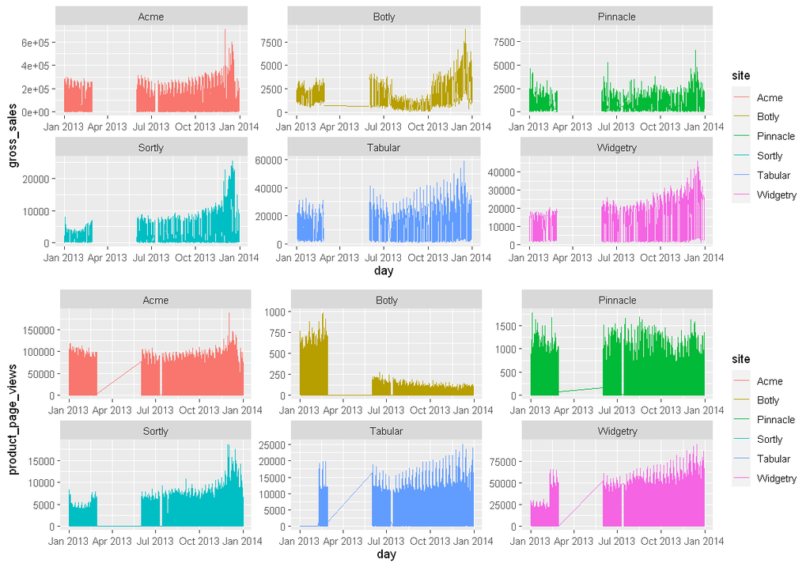

```r
g1 = ggplot(data=df) +
    aes(x=day, y=gross_sales, color=site) +
    geom_line() +
    facet_wrap(~site, nrow=2, scales="free")
    labs(title="Variation of gross sales with time")
g2 = ggplot(data=df) +
    aes(x=day, y=product_page_views, color=site) +
    geom_line() +
    facet_wrap(~site, nrow=2, scales="free")
    labs(title="Variation of product_page_views with time")
ggarrange(g1, g2, nrow = 2)
```

**Inference:** Below are some of the inferences:

1. Dataset doesn't contain data between March to June.
2. Overall for all the sites Gross sales shows a slight increase in trend between September to December 2013 mid week then dropped significantly when approached towards January 2014.
3. Product page views almost remained constant through out the year except between March to June as we don't have data between these months. This means throughout the year people are viewing the products but not buying them.
4. For all of the sites Product page views show a slight increase in trend between October to January. But for Botly shows interesting increase in between January to February end and then rest of the year it shows a general decreasing trend.